# avanti data review and power calc

James Walsh

2025-02-09

## 0.1 **Introduction**

This report provides a high-level summary of the available dataset on **JNV Grade 11 students** and evaluates whether a **randomized evaluation** is feasible by conducting **power calculations**.

## 0.2 **Data Overview**

This section provides a structured summary of the dataset, including the number of records, key variables, and potential limitations. Understanding the dataset’s structure is critical for assessing the feasibility of future analyses, including the planned **A/B test power calculations**.

### 0.2.1 **Dataset Summary**

The dataset contains **test records for Grade 11 students** from India’s **Jawahar Navodaya Vidyalayas (JNVs)**. These students are part of different academic **streams** (Engineering, Medical, and PCMB) and programs (e.g., JNV Nodal, JNV CoE). The dataset captures students’ test performance, school details, and academic classifications.

The dataset consists of:

- **17,685** total records
- **945** unique students
- **23** schools
- **274** unique test instances
- **123** unique test types

These statistics provide an initial sense of **scale** and **coverage**.

### 0.2.2 **Key Variables**

The table below summarizes the most relevant variables:

Summary of Key Variables in the Dataset

|  | Description | Unique_Values | Example_Values |
| --- | --- | --- | --- |
| student_id | Unique identifier for each student | 945 | 263101176 |
| school | Name of the JNV school | 23 | JNV Bangalore Rural |
| stream | Academic track the student is enrolled in | 3 | Engineering |
| test_id | Unique identifier for each test attempt | 274 | 6672184bcf… |
| test_name | Name of the test taken | 123 | CT05-MATHS |
| test_format | Format of the test (e.g., major test, chapter test) | 3 | Major Test |
| start_date | Date when the test was conducted | 14 | 2025-01-17 |
| academic_level | Student’s academic classification | 10 | M2a |
| program_name | The Avanti program the student is part of | 2 | JNV CoE |

### 0.2.3 **Data Completeness & Quality**

To ensure the dataset’s reliability, we checked for **missing values, duplicates, and outliers**. Our analysis confirms that the dataset is **complete and well-structured**, with no major data quality concerns.

Key findings:

- **No missing values** in `percentage` (test scores).
- **No missing values** in `academic_level` (student classification).
- **No duplicate student-test records** detected.

This high level of data completeness strengthens confidence in subsequent analyses. While missing data is not a concern, we will still examine **distribution patterns and potential outliers** in later sections to validate the dataset’s integrity.

## 0.3 High-level summary of the data

This section provides a deeper look into the dataset, building on the Data Overview by exploring key characteristics, distributions, and potential considerations for analysis. The goal is to understand how the data is structured, whether it is balanced, and whether any adjustments might be necessary before proceeding with power calculations for an A/B test.

We focus on the following areas:

Each section will present a short analysis, potential implications, and key takeaways to ensure that the dataset is ready for rigorous testing.

### 0.3.1 **Distribution of Test Scores**

#### 0.3.1.1 **Chapter tests**

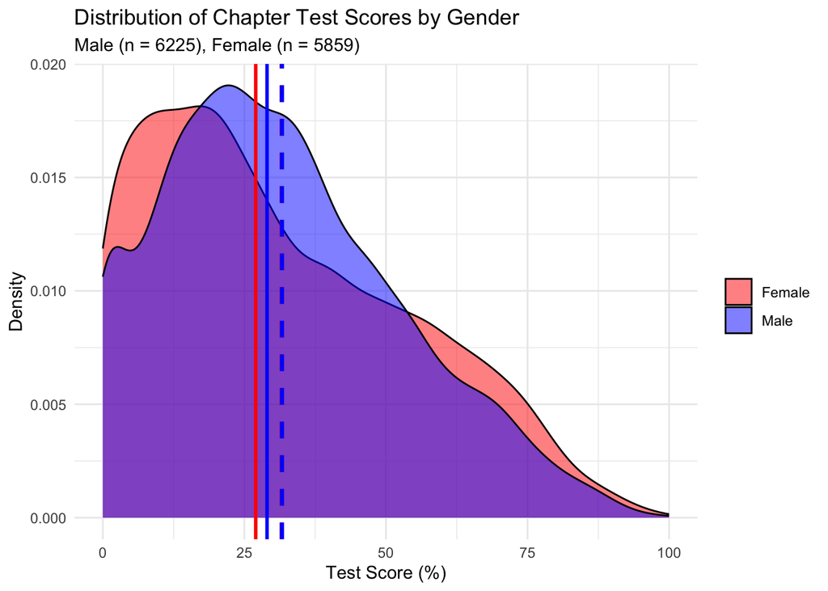

First, let’s examine **chapter test performance**. **Male students** took 6,225 tests, while **female students** took 5,859. The average scores were **31.6%** for males and **31.6%** for females.

### 0.3.2 **Mock tests**

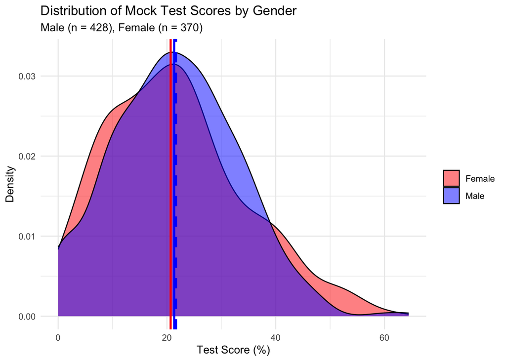

Next, let’s examine mock test performance. **Male students** took **428** tests, while **female students** took **370**. The average scores were **21.6%** for males and **21.5%** for females.

#### 0.3.2.1 **Major tests**

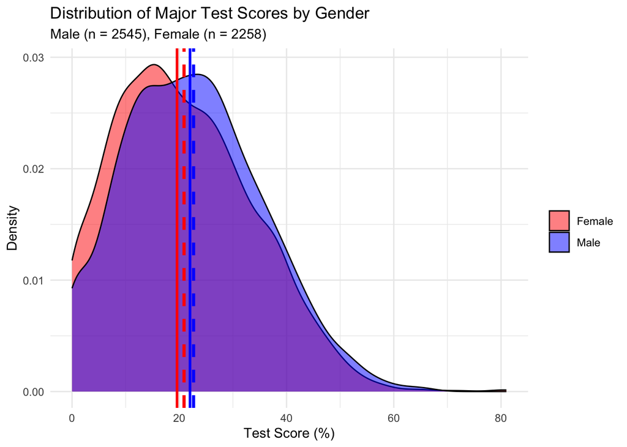

Finally, let’s examine major test performance. **Male students** took **2,545** tests, while **female students** took **2,258**. The average scores were **22.7%** for males and **20.9%** for females.

## 0.4 **Performance in Tests by Stream and Gender**

To further examine student performance, we analyzed **test scores** within each stream, separately for **chapter tests, mock tests, and major tests**.

#### 0.4.0.1 **Engineering**

- **Chapter Tests:** Male students had an average score of **25.9%** (SD = 17), while female students scored **21.8%** (SD = 15.3).
- **Mock Tests:** Male students had an average score of **18.6%** (SD = 10.7), while female students scored **14.4%** (SD = 8.7).
- **Major Tests:** Male students had an average score of **21.6%** (SD = 12.8), while female students scored **15.2%** (SD = 11.1).

#### 0.4.0.2 **Medical**

- **Chapter Tests:** Male students had an average score of **42%** (SD = 23.5), while female students scored **39.2%** (SD = 24.7).
- **Mock Tests:** Male students had an average score of **28%** (SD = 13.8), while female students scored **29%** (SD = 13.2).
- **Major Tests:** Male students had an average score of **28%** (SD = 13.8), while female students scored **27.5%** (SD = 12.5).

## 0.5 **Dates**

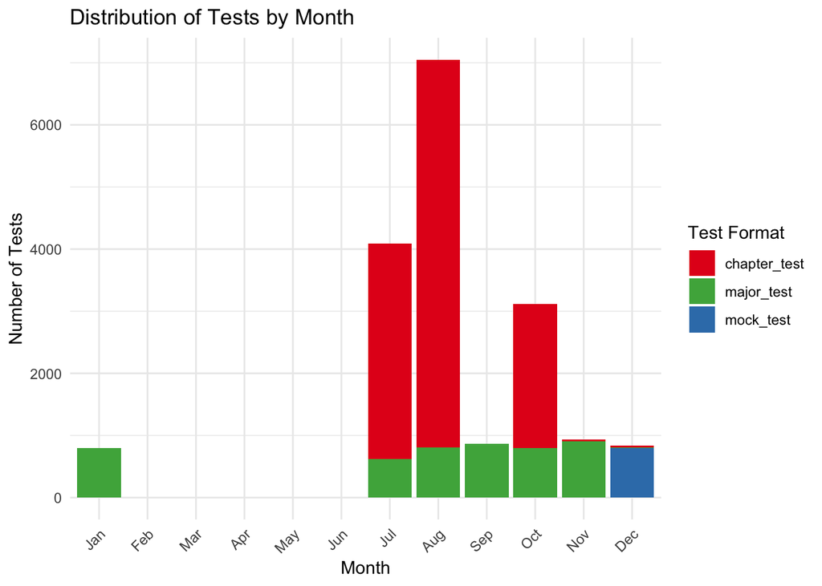

### 0.5.1 **Timing of Tests**

The distribution of test administration over the academic year reveals **substantial variation in test frequency by month and test type**.

The clustering of chapter tests in the **middle of the academic year** suggests a structured testing schedule that prioritizes **frequent formative assessments early on**, while major tests appear to be administered more consistently. The presence of mock tests in December may indicate their role in **preparing students for final evaluations**.

This pattern highlights **key periods of student assessment** and suggests that the timing of tests may have **implications for student performance and preparation strategies**.

## 0.6 **Power Analysis**

The performance gap is most pronounced among **engineering students**, where female students score significantly lower than their male counterparts (**15.2% vs. 21.6%**, SD = **11.1**). This gap suggests a serious challenge in engineering education that merits intervention.

### 0.6.1 **Test Participation and Performance of Female Students**

- **Chapter Tests:** **144** female students took **1,679** tests, with an average score of **21.8%** (SD = **15.3%**).
- **Mock Tests:** **127** female students took **127** tests, with an average score of **14.4%** (SD = **8.7%**).
- **Major Tests:** **162** female students took **845** tests, with an average score of **15.2%** (SD = **11.1%**).

### 0.6.2 **Power calculations**

To assess the feasibility of a randomized experiment targeting girls’ performance in *engineering*, I conducted a **power analysis**. I’ll assume we’re looking to get a .2 standard deviation increase or higher, as this is often taken as a benchmark in education.

This analysis assumes:  
- A **0.2 standard deviation improvement** as a meaningful intervention effect.  
- A **5% significance level** for statistical inference.  
- A **power of 80%**, meaning an 80% probability of detecting a true effect.  
- Equal allocation between the treatment and control groups.

To detect this effect, we’d need to 394 students per group.